# Visualization of networks and communities

2023-05-13

## introduction

## Networks and communities

Network analysis is a powerful tool for understanding complex systems in both the hard and social sciences. By representing data as a network, it is possible to identify communities of similar members, or nodes, that are connected to each other by various relationships.

This allows to gain insights into the structure of the system, as well as the behavior of the nodes within it.

*For example, in social networks, nodes can represent people, and the relationships between them can represent various types of interactions, such as friendships or collaborations. By analyzing the network, researchers can identify clusters of people who are more likely to interact with each other, or who share similar characteristics.*

## Networks and communities: a toy example

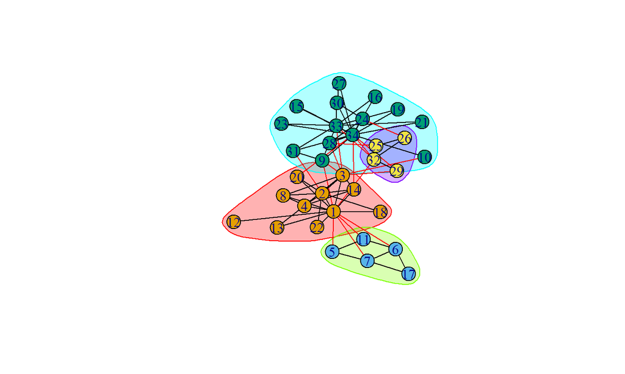

## Communities in large networks

As the size of a network increases, the complexity of the network also increases, making it difficult to represent the network in a simple visual format. As a result, a simple visualization may not provide much clarity in understanding the structure of the network. To gain a better understanding of a large network, more sophisticated visualizations and analysis techniques are needed.

## Contents of this seminar

1. A family of benchmark networks (with built-in communities and controlled *fuzzyness*)
2. Visualization of network and communities (standard and custom layouts, k-core VS strength)
3. Modularity-based community detection
4. robustness of results in *fuzzy* networks
5. consensus and “robustness of membership”
6. sample results in a “labour market network”

## 1 A family of benchmark networks (with built-in communities and controlled *fuzzyness*)

## About LFR benchmark networks

LFR (Lancichinetti-Fortunato-Radicchi) benchmark graphs are synthetic networks used to evaluate the performance of network analysis algorithms. They are generated using a stochastic block model and are designed to have realistic community structure, degree distributions, and other properties of real-world networks.

They are used to test the accuracy of algorithms for network analysis tasks such as community detection, link prediction, and node classification.

Benchmark graphs for testing community detection algorithms, Andrea Lancichinetti, Santo Fortunato, and Filippo Radicchi, Phys. Rev. E 78, 046110 2008

[LFR_benchmark_graph — NetworkX 3.1 documentation](https://networkx.org/documentation/stable/reference/generated/networkx.generators.community.LFR_benchmark_graph.html)

## Building a family of LFR benchmark networks

in Python , networkx LFR_benchmark_graph() [*https://networkx.org/documentation/stable/reference/generated/networkx.generators.community.LFR_benchmark_graph.html*](https://networkx.org/documentation/stable/reference/generated/networkx.generators.community.LFR_benchmark_graph.html)

```python
for mui in range(10,99,20):
    print("generating LFR benchmark. Fuzzyness mu = ", mui/100)
    gb = LFR_benchmark_graph( mu=mui/100,
        n= 250,
        tau1 = 2,
        tau2 = 2,
        average_degree=5,
        min_community=30,
        seed=42)
    gt = add_true_labels(gb)
    nx.write_gml(gt, f"./LFR_graphs/small/FLR_benchmark_{mui}.gml")
```

```
## generating LFR benchmark. Fuzzyness mu =  0.1
## generating LFR benchmark. Fuzzyness mu =  0.3
## generating LFR benchmark. Fuzzyness mu =  0.5
## generating LFR benchmark. Fuzzyness mu =  0.7
## generating LFR benchmark. Fuzzyness mu =  0.9
```

## 2- Visualization of network and communities (standard and custom layouts, k-core VS strength)

## print mu = 10%

…

```
## [1] "Loading graph... ./LFR_graphs/small/FLR_benchmark_10.gml"
```

[output not shown]

## plot function

```r
plot_graph_and_comms <- function(mui , show_comms = TRUE) {
  filename = paste0("./LFR_graphs/small/FLR_benchmark_", mui, ".gml")
  print(paste("Benchmark network ", filename,"and communities (true-labels)"))
  g <- read_graph(filename, format = "gml")
  LO = layout_with_fr(g)
  if (show_comms == TRUE) {
    comms = table(V(g)$community)
    comms = make_clusters(g,
                          membership = V(g)$community,
                          modularity = FALSE)
    plot(
      comms,
      g,
      vertex.color = V(g)$community,
      layout = LO,
      vertex.size = 5,
      vertex.label = NA
    )
  } else {
    plot(
      g,
      vertex.color = V(g)$community,
      layout = LO,
      vertex.size = 5,
      vertex.label = NA
    )

  }
  return(1)
}
```

## sample network ( mu = 0.10 )

```
## [1] "Benchmark network  ./LFR_graphs/small/FLR_benchmark_10.gml and communities (true-labels)"
```

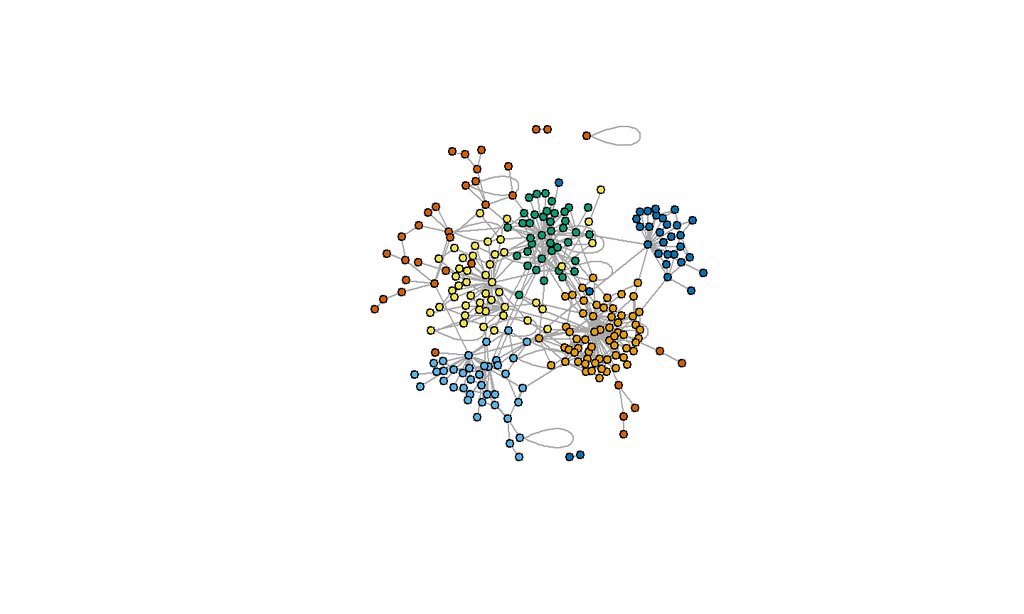

```
## [1] 1
```

```r
plot_graph_and_comms(mui = 10 , show_comms = FALSE)
```

## sample network ( mui = 0.50 )

```
## [1] "Benchmark network  ./LFR_graphs/small/FLR_benchmark_50.gml and communities (true-labels)"
```

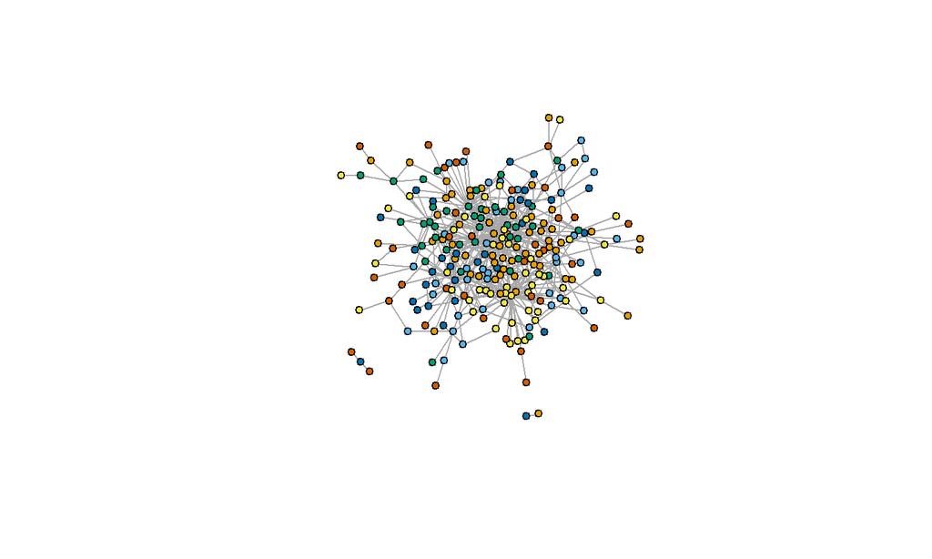

```
## [1] 1
```

```r
plot_graph_and_comms(mui = 50 , show_comms = FALSE)
```

## coreness and strength

K-coreness is a measure of the centrality of a node within a network. It is defined as the largest value of k such that the node belongs to a subgraph of the network that is composed of nodes with at least degree k. A node with a high k-coreness is considered to be more central and influential within the network.

Strength is a measure of the total weight of the connections a node has to other nodes in the network.

## sample network ( mu = 0.50 ): coreness and strength

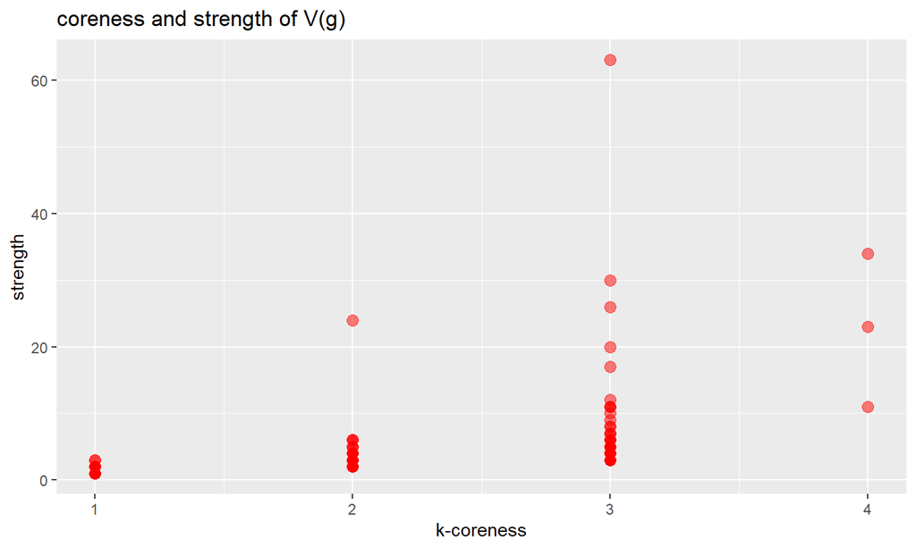

## customized layout

## plot customized layout

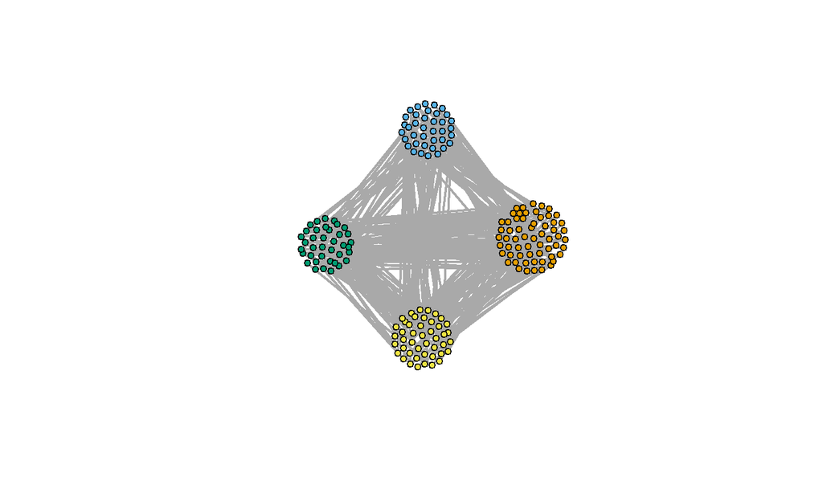

## 3 - unsupervised community detection

## What is a community

the definition of ‘community’ in network analysis depends on the context and the researcher’s goals. for example:

1. a community is a group of nodes that are more densely connected to each other than to the rest of the network.
2. a community is group of nodes that share certain characteristics, such as having similar properties
3. a community is a group of nodes that are more likely to interact with each other than with other nodes in the network.
4. …

## Modularity based community detection (1)

- **Assumptions**:
  - community is subset of nodes that are more densely connected to each other than to the rest of the network
  - partition
  - unsupervised (“true labels” are not available - or not used for community detection)

## Modularity based community detection (2)

- **Definition of Modularity**: Given a network G partitioned into a number of communities Gi, modularity Q(G,Gi) is a function measuring the extent to which edge density is higher within than between communities. i.e. a partition of G that maximises Q results in communities that have strong internal connections and weak connections with other communities

*A partition with a higher modularity score indicates that the edges within the partition are denser than the edges between partitions, suggesting strong internal connections and weak connections with other communities. **The optimal partition maximizes modularity***

## Louvain community detection algorithm

Modularity optimization, by means of a hierarchical approach.

1. Initiates by partitioning the network so that each vertex is assigned to a single community.
2. Starting with a random vertex Vi, it computes the potential variation in modularity ΔQi j that would occur by aggregating Vi to each of its neighbours Vj.
3. If max(ΔQik) > 0 then, Vi is removed from its original community and aggregated to the neighbour Vk that maximises the gain.
4. The number of communities is thus reduced, and process is repeated sequentially for all other vertices until max(ΔQik)≤0 .

As all methods based on modularity optimization it is biased by some intrinsic limits

- greedy (find local optima)
- Results depend on user-defined parameters
- results depend on random initialisation and sequence of vrtices

## 4. robustness of results in *fuzzy* networks

## a function to test the distribution of results

## sample network ( mu = 0.50 ): coreness and strength

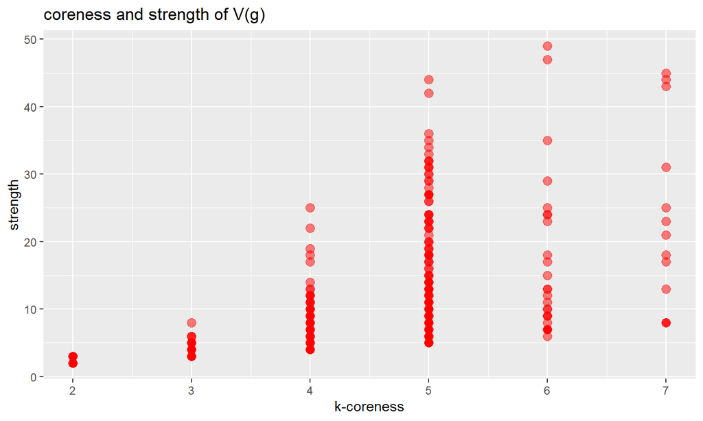

## Community detection: single trial

```
## [1] "Analysing  ./LFR_graphs/benchmark/FLR_benchmark_20.gml ..."
## [1] "Built-in communities:  37"
## [1] "Community detection results"
## [1] "Modularity:  0.723266362948337"
## [1] "Normalized Mutual Information 0.918103507039529"
##
##  1  2  3  4  5  6  7  8  9 10 11 12 13 14 15 16 17 18 19 20 21 22 23 24 25 26
## 42 67 29 20 42 53 29 24 53 30 40 23 43 40 41 30 56 32 49 34 24 44 20 44 36 28
## 27
## 26
```

## Community detection: repeated trials

```
## [1] "29 communities found"
## [1] "26 communities found"
## [1] "28 communities found"
## [1] "28 communities found"
## [1] "26 communities found"
## [1] "29 communities found"
## [1] "29 communities found"
## [1] "28 communities found"
## [1] "27 communities found"
## [1] "29 communities found"
```

## Community detection: 1000 trials

## results (1)

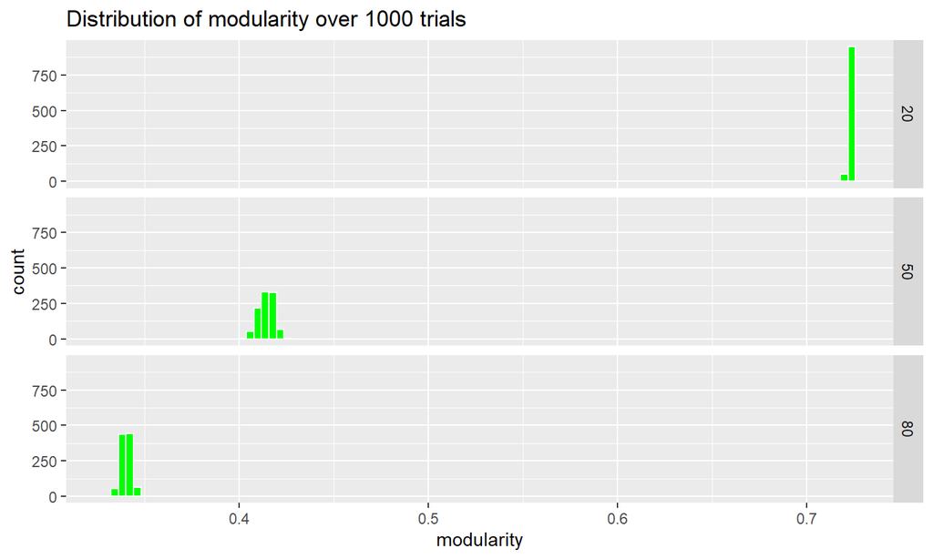

## results (2)

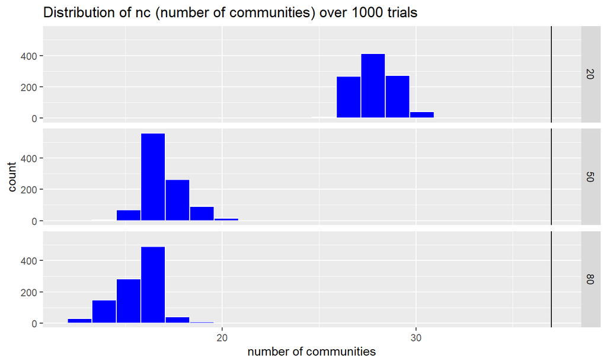

## results (3)

[figure not shown]

## results (4)

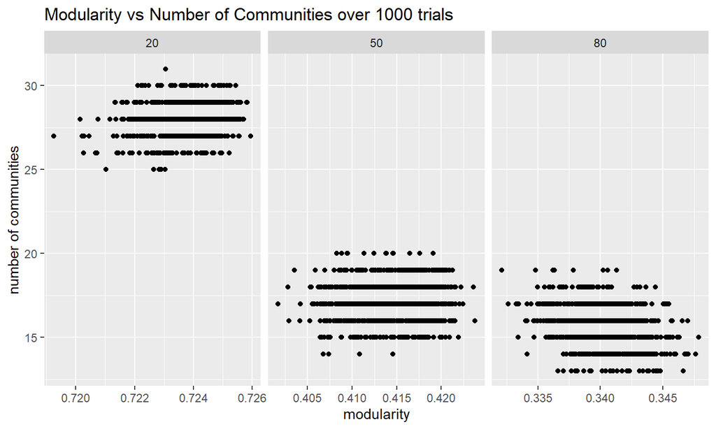

## results (5)

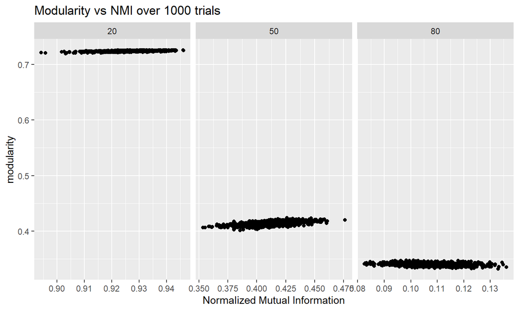

## 5. consensus and “robustness of membership”

## inspired by ’random forrest” algorithm

Random Forest is an ensemble machine learning algorithm that combines the results produced by multiple independent instances of ‘regression tree’ (or ‘decision tree’) to obtain predictive performance than could be obtained from any of the ‘trees’ alone.

The algorithm builds N = 500 trees, each based on a randomly selected subset of features from the training dataset. The final prediction is made by averaging the predictions (or selecting the mode) of all the N trees.

**note**: Random Forest is a *supervised* algorithm (community detection is *unsupervised*)

## Consensus community detection (CCD)

CCD can be used to enhance both the stability and the accuracy of the resulting partitions, reducing dependence on user-defined parameters and random initialization

Principles:

```
-   **Independent trials**

-   **Consensus**

-   **Pruning**
```

## Consensus community detection (CCD)

**Independent trials:** The Louvain community detection algorithm is repeated Ni times, and at each iteration only a part of the information in the network is used i.e. a randomly chosen fraction α of edges is assigned a weight W0 (small, but non-zero). The resulting network is not losing connectivity, but edges associated with W0 are more likely to be assigned to different community at each iteration

## Consensus community detection (CCD)

**Consensus**: the consensus algorithm counts how many times a pair of vertices Vi and Vj are assigned to the same community and assigns a *proportion of membership* PVij ∈ [0,1].

Vertices that are strongly connected to one another are always assigned to the same community and have PVij = 1; lower values of Pvij indicate that the vertex is not strongly connected to its neighbors, and it may be assigned to two or more communities with some degree of confidence.

## Consensus community detection (CCD)

**Pruning**: The algorithm creates a meta-community labelled as “community 0” defined by regular equivalence (i.e. vertices covering the same “marginal” role in the network):

- Vertices with max(Pvij) < 0.5
- Trivially small communities of size Scommunity < Scmin ,
- Trivially small communities of weight Wcommunity < Wcmin

## CCD parameters

Independent trials

- - N repetitions: independent repetitions of the whole procedure
- - N trials: independent trials of modularity based community detection

Consensus

- Alpha: fraction of edges that is assigned a weight W0. *default 0.05*
- Epsilon: to set the appropriate value of W0 = min(Wi * Epsilon) *default 0.01*
- Resolution: parameter of Louvain Community Detection *default 1.0*
- P_threshold: proportion of membership threshold *default 0.5*

## simulation plan (1)

## simulation plan (2)

We simulate several LFR networks setting different parameters hat reproduce some of the key structural features of a network of interest (labour market network of Friuli Venezia Giulia)

- N=1000
- Average degree = 10
- Community size min = 20 max = 50 Tau1 = 2
- Tau2 = 3
- mu { 0.1, 0.2, …. 0.9 }
- Mu is the crucial parameter for our test, as it governs the fuzziness of communities.

## results (1)

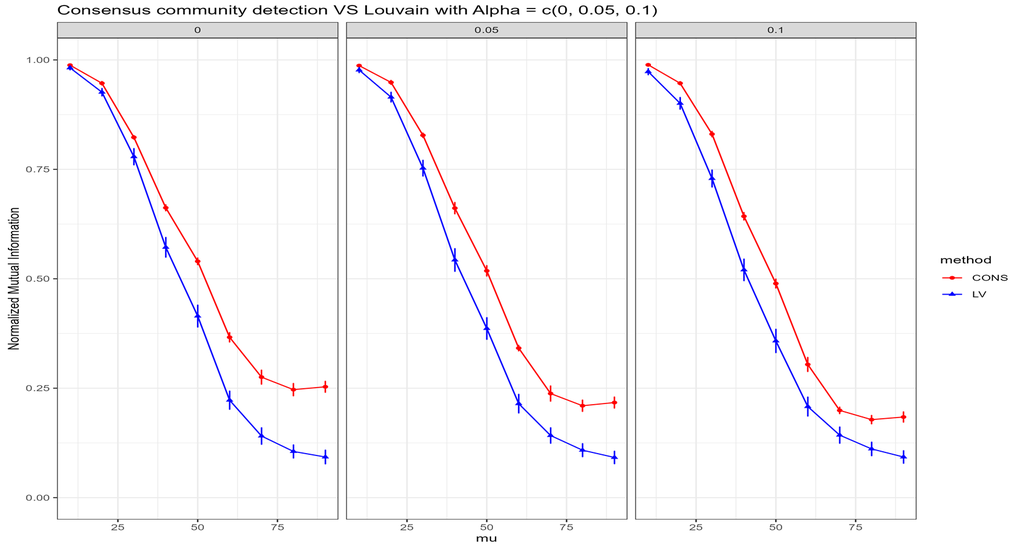

## results (2)

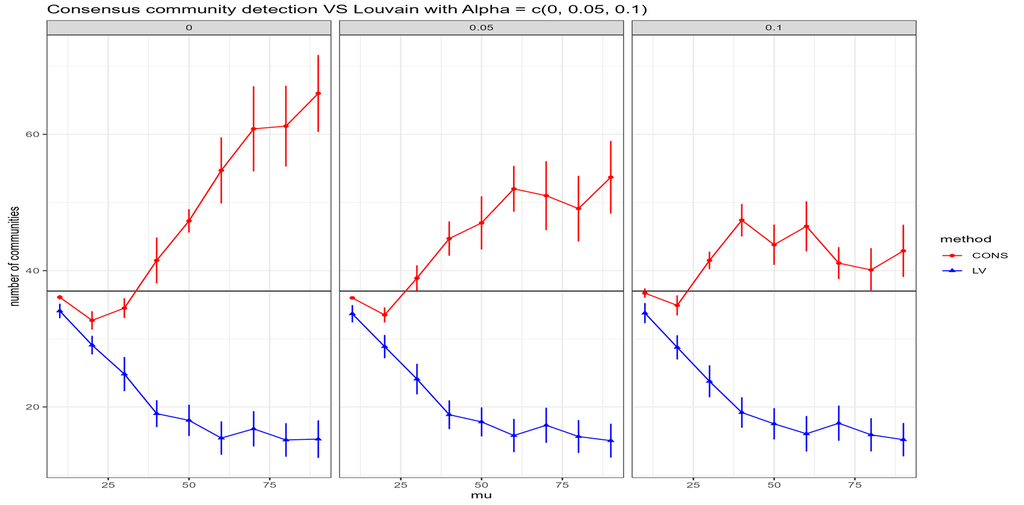

## results (3)

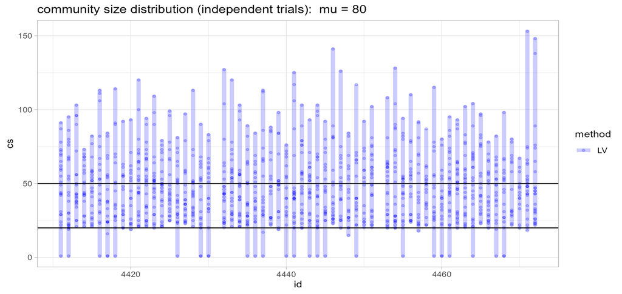

## 6. sample results in a “labour market network”

## Coreness and strength

## Communities

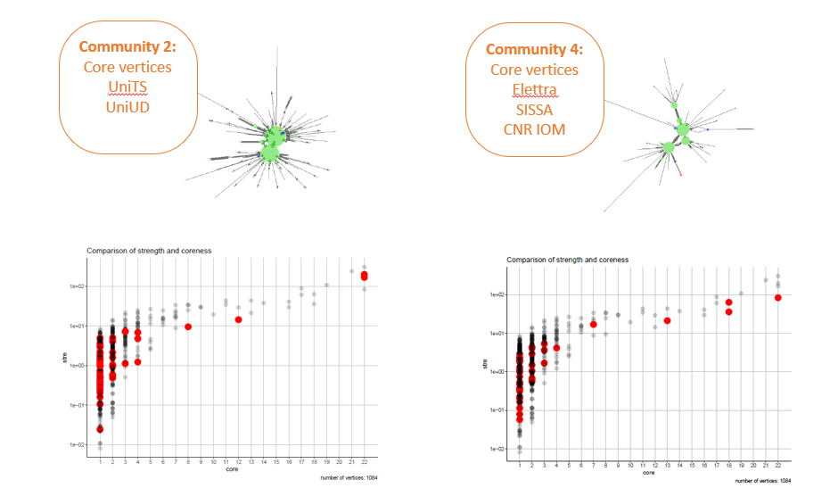

## Community “0”

Community 0 is a community of regular equivalent organizations or organisation whose membership is strongly dependent on the random initialisation of the community detection algorithm

- Disconnected components
- Communities identified by consensus algorithm that fall below thresholds of size of weight
- Nodes that are assigned to different commuities at each run of Louvain community detection

## Community “0”

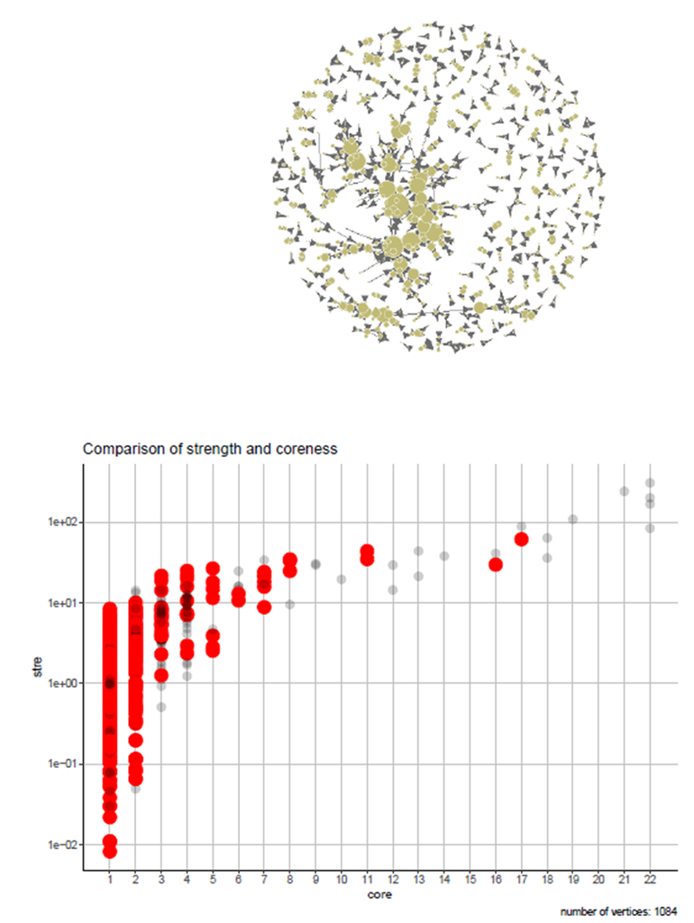